# 배열(Array) 구조 이해하기

- 소프트웨어에서 배열은 하나의 자료형을 기준으로 순서가 있는 원소의 나열된 자료 구조이다.
- 파이썬에서도 순차적으로 원소를 나열하는 배열 형태의 리스트(list)를 제공한다.
- 일반적인 배열과 리스트의 차이는 리스트는 다양한 자료형인 클래스의 객체를 원소로 받는 것이다.
- 다차원 배열은 배열의 기본 특징에 따라 모든 원소가 하나의 자료헝이다.

# 파이썬 리스트 구조 이해하기

- 파이썬에서 제공하는 리스트(list)는 파이썬으로 만들어지는 모든 클래스의 객체를 원소로 받을 수가 있다.
- 배열의 구조처럼 하나의 자료형을 갖는 최상위 클래스를 object 라고 한다.
- 리스트는 객체가 만들어질 때 특정 자료형을 지정하지 않고 모든 객체를 받아서 처리한다.
- 배열 구조에서 순차적으로 원소를 관리하는 것은 아주 중요하다. 이 순서 정보를 인덱스(Index) 라고한다.
- 내부의 원소를 검색 할 때 인덱스 정보를 가지고 색인 검색을 수행한다.
- 리스트의 부분 리스트를 만들 때도 인덱스 정보를 사용해서 슬라이스 객체를 만든 후에 검색을 수행하면 슬라이스(slice) 검색된 부분의 리스트를 만들게 된다.

# 리스트 구조 예제

```python
l = [[1,2,3], [4,5,6]]
```

```python
type(l)
```

```
list
```

실제 리스트의 원소를 순차적으로 검색하면 인덱스 번호 0은 첫 번째 원소를 조회한다. 인덱스 1 이면 두 번째 원소를 조회한다.

```python
l[0]
```

```
[1, 2, 3]
```

```python
l[1]
```

```
[4, 5, 6]
```

이 리스트 객체의 모든 원소를 검색할때는 순환문을 사용해서 내부를 색인연산으로 조회한다.

```python
for i, a in enumerate(l) :
    for j,b in enumerate(a) :
        print(l[i][j])
```

```
1
2
3
4
5
6
```

# NumPy

- 넘파이는 파이썬 수치 계산 라이브러리이다.
- 넘파이를 사용하면 간단하게 행렬 계산을 할 수도 있다.
- 머신러닝을 할때는 Numpy를 빼놓을 수 없다.

# NumPy 배열

많은 숫자 데이터를 하나의 변수에 넣고 관리 할 때 리스트는 속도가 느리고 메모리를 많이 차지하는 단점이 있다.

**배열(array)**을 사용하면 적은 메모리로 데이터를 빠르게 처리할 수 있다. 배열은 리스트와 비슷하지만 다음과 같은 점에서 다르다.

1. 모든 원소가 같은 자료형이어야 한다.
2. 원소의 갯수를 바꿀 수 없다.

파이썬은 자체적으로 배열 자료형을 제공하지 않는다.

따라서 배열을 구현한 다른 패키지를 임포트해야 한다.

파이썬에서 배열을 사용하기 위한 표준 패키지는 **NumPy(보통 "넘파이"라고 발음한다)** 이다.

NumPy는 수치해석용 파이썬 패키지이다.

다차원의 배열 자료구조 클래스인 ndarray 클래스를 지원하며 벡터와 행렬을 사용하는 선형대수 계산에 주로 사용된다.

내부적으로는 BLAS 라이브러리와 LAPACK 라이브러리를 사용하고 있으며 C로 구현된 CPython에서만 사용할 수 있다.

NumPy의 배열 연산은 C로 구현된 내부 반복문을 사용하기 때문에 파이썬 반복문에 비해 속도가 빠르며 **벡터화 연산(vectorized operation)**을 이용하여 간단한 코드로도 복잡한 선형 대수 연산을 수행할 수 있다. 또한 **배열 인덱싱(array indexing)**을 사용한 질의(Query) 기능을 이용하여 간단한 코드로도 복잡한 수식을 계산할 수 있다.

# 다차원 배열의 구조 이해하기

- 넘파이 모듈의 기본 배열은 다차원 배열인 ndarray 클래스의 객체이다.
- 이 배열은 하나의 자료형으로 만들어진 원소들을 보관하는 컨테이너이다.
- 다차원 배열의 객체가 만들어지면 데이터는 메모리에 넣고 이 데이터에 대한 다양한 메타정보는 이 객체의 속성으로 관리한다.

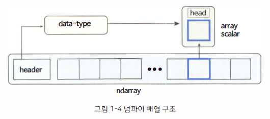

## NumPy 패키지 임포트

배열을 사용하기 위해서는 우선 다음과 같이 NumPy 패키지를 임포트한다.

NumPy는 np라는 이름으로 임포트하는 것이 관례이다.

```python
!pip install numpy
```

```python
import numpy as np

np.__version__
```

```
'1.18.5'
```

넘파이 모듈의 별칭과 ndarray 이름을 print 함수에 인자로 전달하면 클래스라는 것을 알 수 있다.

이 클래스의 이름의 뜻은 n-dimensinrray 이며 다차원 배열을 만들 수 있다.

```python
print(np.ndarray)
```

```
<class 'numpy.ndarray'>
```

파이썬 클래스에는 클래스의 이름을 가지고 있다.

클래스 이름을 조회 하려면 클래스 이름 다음에 **name** 속성을 작성해서 실행한다.

이름은 문자열 ndarray를 표시한다.

```python
np.ndarray.__name__
```

```
'ndarray'
```

.

파이썬에서 클래스를 작성하면 속성과 메소드를 관리하는 이름공간(names pace)이 만들어진다.

다차원 배열 ndarray 클래스의 이름공간에 있는 var 를 확인해본다.

이 var 가 어떤 클래스로 만들어졌는지 확인하려면 파이썬에서 제공하는 type 클래스에 인자로 전달해주면 된다.

출력된 결과를 확인하면 method_descriptor 이다.

C 언어로 만들어진 method_descriptor 클래스의 객체를 var 라는 이름에 저장한 것을 알 수 있다.

```python
type(np.ndarray.var)
```

```
method_descriptor
```

- 내부의 if 문을 사용해서 ndarray 클래스의 이름공간인 **dict** 에 문자열을 색인 검색으로 객체를 가져 와서 var 와 동일하지 않는 객체만을 추출한다.
- 추출된 결과는 ndarray 클래스에서 관리하는 속성만 출력된다.

```python
for i in dir(np.ndarray) :
    if not i.startswith("_") :
        if type(np.ndarray.__dict__[i]) != type(np.ndarray.var) :
            print(i)
```

```
T
base
ctypes
data
dtype
flags
flat
imag
itemsize
nbytes
ndim
real
shape
size
strides
```

## 1차원 배열 만들기

NumPy의 `array`라는 함수에 리스트를 넣으면 배열로 변환해 준다. 따라서 1 차원 배열을 만드는 방법은 다음과 같다.

```python
ar = np.array([0, 1, 2, 3, 4, 5, 6, 7, 8, 9])
ar
```

```
array([0, 1, 2, 3, 4, 5, 6, 7, 8, 9])
```

리스트와 비슷해 보이지만 `type` 명령으로 자료형을 살펴보면 ndarray임을 알 수 있다.

```python
type(ar)
```

```
numpy.ndarray
```

만들어진 `ndarray` 객체의 표현식(representation)을 보면 바깥쪽에 array()란 것이 붙어 있을 뿐 리스트와 동일한 구조처럼 보인다. 그러나 배열 객체와 리스트 객체는 많은 차이가 있다.

우선 리스트 클래스 객체는 각각의 원소가 다른 자료형이 될 수 있다. 그러나 배열 객체 객체는 C언어의 배열처럼 연속적인 메모리 배치를 가지기 때문에 모든 원소가 같은 자료형이어야 한다. 이러한 제약사항이 있는 대신 원소에 대한 접근과 반복문 실행이 빨라진다.

## 벡터화 연산

배열 객체는 배열의 각 원소에 대한 반복 연산을 하나의 명령어로 처리하는 **벡터화 연산(vectorized operation)** 을 지원한다.

예를 들어 다음처럼 여러개의 데이터를 모두 2배 해야 하는 경우를 생각하자.

넘파이로 행렬 계산을 하려면 일단 NumPy 배열을 생성(또는 초기화) 해야 합니다

[figure not shown]

```python
data = [0, 1, 2, 3, 4, 5, 6, 7, 8, 9]
```

for 반복문을 사용하면 다음과 같이 구현할 수 있다.

```python
answer = []
for di in data:
    answer.append(2 * di)
answer
```

```
[0, 2, 4, 6, 8, 10, 12, 14, 16, 18]
```

하지만 벡터화 연산을 사용하면 다음과 같이 for 반복문이 없이 한번의 연산으로 할 수 있다. 계산 속도도 반복문을 사용할 때 보다 훨씬 빠르다.

```python
x = np.array(data)
x
```

```
array([0, 1, 2, 3, 4, 5, 6, 7, 8, 9])
```

```python
2 * x
```

```
array([ 0,  2,  4,  6,  8, 10, 12, 14, 16, 18])
```

참고로 일반적인 리스트 객체에 정수를 곱하면 객체의 크기가 정수배 만큼으로 증가한다.

```python
L = [0, 1, 2, 3, 4, 5, 6, 7, 8, 9]
print(2 * L)
```

```
[0, 1, 2, 3, 4, 5, 6, 7, 8, 9, 0, 1, 2, 3, 4, 5, 6, 7, 8, 9]
```

벡터화 연산은 비교 연산과 논리 연산을 포함한 모든 종류의 수학 연산에 대해 적용된다.

```python
a = np.array([1, 2, 3])
b = np.array([10, 20, 30])
```

```python
2 * a + b
```

```
array([12, 24, 36])
```

```python
a == 2
```

```
array([False,  True, False])
```

```python
b > 10
```

```
array([False,  True,  True])
```

```python
(a == 2) & (b > 10)
```

```
array([False,  True, False])
```

# NumPy 모듈 선언

```python
import numpy as np
```

.

# NumPy 배열 초기화

넘파이로 행렬 계산을 하려면 일단 NumPy 배열을 생성(또는 초기화) 해주어야 한다

```python
a = np.array([1,2,3,4,5])
print(a)
print(type(a))

# 결과를 실행하면 다음과 같이 출력됩니다.
# 또한 NumPy 배열 상태는 numpy.ndarray 객체라는 것을 알 수 있습니다
# N-dimensional array : 다차원배열구조
```

```
[1 2 3 4 5]
<class 'numpy.ndarray'>
```

## 1차원 배열 만들기

NumPy의 `array`라는 함수에 리스트를 넣으면 배열로 변환해 준다.

따라서 1 차원 배열을 만드는 방법은 다음과 같다.

```python
ar = np.array([0, 1, 2, 3, 4, 5, 6, 7, 8, 9])
ar
```

```
array([0, 1, 2, 3, 4, 5, 6, 7, 8, 9])
```

리스트와 비슷해 보이지만 `type` 명령으로 자료형을 살펴보면 ndarray임을 알 수 있다.

```python
type(ar)
```

```
numpy.ndarray
```

만들어진 `ndarray` 객체의 표현식(representation)을 보면 바깥쪽에 array()란 것이 붙어 있을 뿐 리스트와 동일한 구조처럼 보인다. 그러나 배열 객체와 리스트 객체는 많은 차이가 있다.

우선 리스트 클래스 객체는 각각의 원소가 다른 자료형이 될 수 있다. 그러나 배열 객체 객체는 C언어의 배열처럼 연속적인 메모리 배치를 가지기 때문에 모든 원소가 같은 자료형이어야 한다. 이러한 제약사항이 있는 대신 원소에 대한 접근과 반복문 실행이 빨라진다.

## 벡터화 연산

```python
data = [0, 1, 2, 3, 4, 5, 6, 7, 8, 9]
```

for 반복문을 사용하면 다음과 같이 구현할 수 있다.

```python
answer = []
for di in data:
    answer.append(2 * di)
answer
```

```
[0, 2, 4, 6, 8, 10, 12, 14, 16, 18]
```

하지만 벡터화 연산을 사용하면 다음과 같이 for 반복문이 없이 한번의 연산으로 할 수 있다. 계산 속도도 반복문을 사용할 때 보다 훨씬 빠르다.

```python
x = np.array(data)
x
```

```
array([0, 1, 2, 3, 4, 5, 6, 7, 8, 9])
```

```python
2 * x
```

```
array([ 0,  2,  4,  6,  8, 10, 12, 14, 16, 18])
```

참고로 일반적인 리스트 객체에 정수를 곱하면 객체의 크기가 정수배 만큼으로 증가한다.

```python
L = [0, 1, 2, 3, 4, 5, 6, 7, 8, 9]
print(2 * L)
```

```
[0, 1, 2, 3, 4, 5, 6, 7, 8, 9, 0, 1, 2, 3, 4, 5, 6, 7, 8, 9]
```

벡터화 연산은 비교 연산과 논리 연산을 포함한 모든 종류의 수학 연산에 대해 적용된다.

```python
a = np.array([1, 2, 3])
b = np.array([10, 20, 30])
```

```python
2 * a + b
```

```
array([12, 24, 36])
```

```python
a == 2
```

```
array([False,  True, False])
```

```python
b > 10
```

```
array([False,  True,  True])
```

```python
(a == 2) & (b > 10)
```

```
array([False,  True, False])
```

## 2차원 배열 만들기

`ndarray` 는 N-dimensional Array의 약자이다. 이름 그대로 1차원 배열 이외에도 2차원 배열, 3차원 배열 등의 다차원 배열 자료 구조를 지원한다. 2차원 배열은 **행렬(matrix)**이라고 하는데 행렬에서는 가로줄을 **행**(row)이라고 하고 세로줄을 **열**(column)이라고 부른다.

다음과 같이 리스트의 리스트(list of list)를 이용하면 2차원 배열을 생성할 수 있다. 안쪽 리스트의 길이는 행렬의 열의 수 즉, 가로 크기가 되고 바깥쪽 리스트의 길이는 행렬의 행의 수, 즉 세로 크기가 된다. 예를 들어 2 x 3 배열은 다음과 같이 만든다.

```python
c = np.array([[0, 1, 2], [3, 4, 5]])  # 2 x 3 array
c
```

```
array([[0, 1, 2],
       [3, 4, 5]])
```

2차원 배열의 행과 열의 갯수는 다음처럼 구한다.

```python
# 행의 갯수
len(c)
```

```
2
```

```python
# 열의 갯수
len(c[0])
```

```
3
```

## 연습 문제 1

#### NumPy를 사용하여 다음과 같은 행렬을 만든다.

```
10 20 30 40
50 60 70 80
```

.

# NumPy 2차원 행렬

```python
# NumPy로 2차원 행렬을 만들때는 다음과 같이 작성한다.

b = np.array([[1,2,3], [4,5,6]])
print(b)
```

```
[[1 2 3]
 [4 5 6]]
```

.

#### np.zeros() 함수를 사용하여 한번에 배열을 0으로 초기화해서 생성할 수 도 있다.

```python
print(np.zeros(10))
print(np.zeros((3,2)))

# np.zeros()에 튜플로 여러 개의 값을 지정하면 지정한 차원의 배열을 생성하고 0으로 초기화할 수 있다.
```

```
[0. 0. 0. 0. 0. 0. 0. 0. 0. 0.]
[[0. 0.]
 [0. 0.]
 [0. 0.]]
```

.

#### np.ones() 함수를 사용하여 한번에 배열을 1로 초기화해서 생성할 수 도 있다.

[figure not shown]

```python
print(np.ones(10))
print(np.ones((3,2)))
```

```
[1. 1. 1. 1. 1. 1. 1. 1. 1. 1.]
[[1. 1.]
 [1. 1.]
 [1. 1.]]
```

.

#### np.arange() 함수를 사용하여 범위를 기반으로 배열 생성

```python
print(np.arange(5))
print()
print(np.arange(2, 9))
print()
print(np.arange(5, 8, 0.5))
```

```
[0 1 2 3 4]

[2 3 4 5 6 7 8]

[5.  5.5 6.  6.5 7.  7.5]
```

.

# 행렬 계산

```python
a = np.array([1,2,3,4,5])
b = a * 2
print(b)
```

```
[ 2  4  6  8 10]
```

실행결과 포인트는 2번째 줄의 계산 부분이다.

NumPy 배열에 2를 곱하면 배열의 모든 요소에 2가 곱해진다.

.

```python
x = np.arange(10)
y = 3 * x + 5
print(y)
```

```
[ 5  8 11 14 17 20 23 26 29 32]
```

.

# NumPy 배열의 차원 확인

머신러닝에서는 NumPy로 다차원 배열을 다루는 경우가 많이 발생한다.

데이터가 복잡해지면 차원을 확인해야 하는 경우도 많다.

이럴 경우 NumPy 배열의 **shape** 속성을 사용한다.

```python
a = np.array([[1,2,3], [4,5,6]])
print(a.shape)
```

```
(2, 3)
```

.

```python
b = np.array([[1,2,3], [4,5,6], [7,8,9]])
print(b.shape)
```

```
(3, 3)
```

.

# NumPy 배열의 차원 수 변환

넘파이 배열은 배열의 차원 수를 쉽게 변환할 수 있다.

2차원 배열에 **flatten()** 메서드를 사용하면 쉽게 1차원 배열로 변환된다.

```python
a = np.array([[1,2,3], [4,5,6]])
print('a = ', a)
print()
b = a.flatten()
print('b = ', b)
```

```
a =  [[1 2 3]
 [4 5 6]]

b =  [1 2 3 4 5 6]
```

.

**reshape()** 메서드를 사용하면 원하는 차원 수로 변환할 수 있다.

```python
a = np.array([[1,2,3], [4,5,6]])
print(a)
print()
print(a.reshape(3,2))
```

```
[[1 2 3]
 [4 5 6]]

[[1 2]
 [3 4]
 [5 6]]
```

.

# NumPy 배열 요소에 접근하는 방법

NumPy 배열도 파이썬 표준 배열처럼 요소에 접근할 수 있으며, 특정 범위에 있는 값을 추출할 수 있다.

```python
v = np.array([[1,2,3], [4,5,6], [7,8,9]])
a = v[0]
b = v[1:]
c = v[:, 0]

print('a = ', a)
print()
print('b = ', b)
print()
print('c = ', c)
```

```
a =  [1 2 3]

b =  [[4 5 6]
 [7 8 9]]

c =  [1 4 7]
```

변수 a는 v에서 0번째 요소를 추출한 것이다.

변수 b는 1 번째 이후 요소를 추출한 것이다.

변수 c는 2차원 배열 내부에 있는 1차원 배열의 0번째 요소를 추출한 것이다 .

.

파이썬 NumPy 에서 배열의 차원(Dimension)을 재구조화, 변경하고자 할 때 reshape() 메소드를 사용한다.

예를 들어, 3개의 행과 4개의 열로 구성된 2차원의 배열로 재설정하고 싶으면 reshape(3, 4) 처럼 reshape()의 매개변수로 변경하고자 하는 배열의 행과 열의 차원을 정수로 입력해준다.

그런데 reshape(-1, 2) 혹은 reshape(3, -1) 처럼 reshape() 메소드 안에 '-1'이 들어가 있는 경우가 있다.

이때 reshape()의 '-1'이 의미하는 바는, 변경된 배열의 '-1' 위치의 차원은 "원래 배열의 길이와 남은 차원으로 부터 추정"이 된다는 뜻이다.

(One shape dimension can be -1. In this case, the value is inferred from the length of the array and remaining dimensions.)

#### 먼저 NumPy 라이브러리를 import 하고 3x4 차원의 예제 배열을 만들어보겠다.

(일상적으로 사용하는 reshape() 의 사용 예제)

```python
import numpy as np
x = np.arange(12).reshape(3, 4)
x.shape
x
```

```
array([[ 0,  1,  2,  3],
       [ 4,  5,  6,  7],
       [ 8,  9, 10, 11]])
```

.

이제 reshape() 의 행(row) 차원 위치에 '-1'을 넣으면 어떻게 재구조화가 되는지 살펴보겠다.

총 12개의 원소가 들어있는 배열 x에 대해서 x.reshape(-1, 정수) 를 해주면 '열(column)' 차원의 '정수'에 따라서 12개의 원소가 빠짐없이 배치될 수 있도록 '-1'이 들어가 있는 '행(row)' 의 개수가 가변적으로 정해짐을 알 수 있다.

### reshape(-1, 정수) : 행(raw) 위치에 '-1'이 들어있을 경우

```python
# 행(raw) 위치에 '-1'이 들어있을 경우¶

x.reshape(-1, 1)    # shape(12,1)
```

```
array([[ 0],
       [ 1],
       [ 2],
       [ 3],
       [ 4],
       [ 5],
       [ 6],
       [ 7],
       [ 8],
       [ 9],
       [10],
       [11]])
```

```python
x.reshape(-1, 2)    # shape(6, 2)
```

```
array([[ 0,  1],
       [ 2,  3],
       [ 4,  5],
       [ 6,  7],
       [ 8,  9],
       [10, 11]])
```

```python
x.reshape(-1, 3)    # shape(4, 3)
```

```
array([[ 0,  1,  2],
       [ 3,  4,  5],
       [ 6,  7,  8],
       [ 9, 10, 11]])
```

```python
x.reshape(-1, 4)    #  shape(3, 4)
```

```
array([[ 0,  1,  2,  3],
       [ 4,  5,  6,  7],
       [ 8,  9, 10, 11]])
```

.